# Car Prices

## Background

When I was in high school, I wanted a Pontiac. I don’t remember the reason… I just did. I ended receiving a Chevrolet Malibu at the end of my high school career. Using this data set, I want to see the relationship between the mileage a car has and the price of a car. In particular, I want to look at those cars of the Chevrolet or Pontiac make. In other words, I will be comparing the mileage of a car to its price for different makes of cars.

## Hypotheses and Models

The model being used in this analysis is as follows:
$$\underbrace{Y_i}_\text{Price of vehicle} =
\overbrace{\beta_0}^\text{Chevy car Price if mileage is zero} +
\overbrace{\beta_1}^\text{Change in price with respect to mileage}
\underbrace{X_i}_\text{Mileage of car} +
\overbrace{\beta_2}^\text{Change in y-intercept due to Make}X_\text{2i}
+ \overbrace{\beta_3}^\text{Change in slope due to
Make}X_\text{1i}X_\text{2i} + \epsilon_i \quad \text{Where} \ \epsilon_i
\sim N(0, \sigma^2)$$
Since I am using multiple linear regression, the thing that I am going to be testing for is whether or not this data has a linear relationship at all. To do this, I will be using the following hypotheses:
$$H_0: \beta_1 = 0$$
$$H_a: \beta_1 \neq 0$$
Of course, this hypothesis only refers to the slope of the line for the Chevrolet make.

I also want to see if the fact that the car is a Pontiac makes a difference in the slope of the model. I will do that by using these hypotheses:

$$H_0: \beta_3 = 0$$
$$H_a: \beta_3 \neq 0$$

## Plots

Here we can see a scatterplot of the data without the trendlines drawn on it.

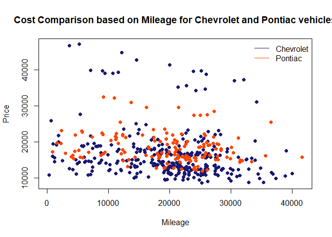

```r
CarPrices1 <- filter(CarPrices, Make == "Pontiac" | Make == "Chevrolet")
CarPrices1$Make <- as.factor(CarPrices1$Make)
prices.lm <- lm(Price ~ Mileage + Make + Mileage:Make, data = CarPrices1)
palette(c("midnightblue", "orangered"))
plot(Price ~ Mileage, data = CarPrices1, col = as.factor(Make), pch = 16, main = "Cost Comparison based on Mileage for Chevrolet and Pontiac vehicles")
legend("topright", legend = c("Chevrolet", "Pontiac"), bty = "n", lty = 1, col = palette())
```

Below, I will try to see if the test that I perform is appropriate in this instance. I will do this by using three diagnostic plots. A Residuals vs. Fitted plot which will assess the linearity and the variance assumptions, a Q-Q Plot of the Residuals which will test the normality of the residuals, and a Residuals vs. Order plot which tests to see if the errors are independent of one another. These plots have to do with the fundamental assumptions of performing a linear regression analysis.

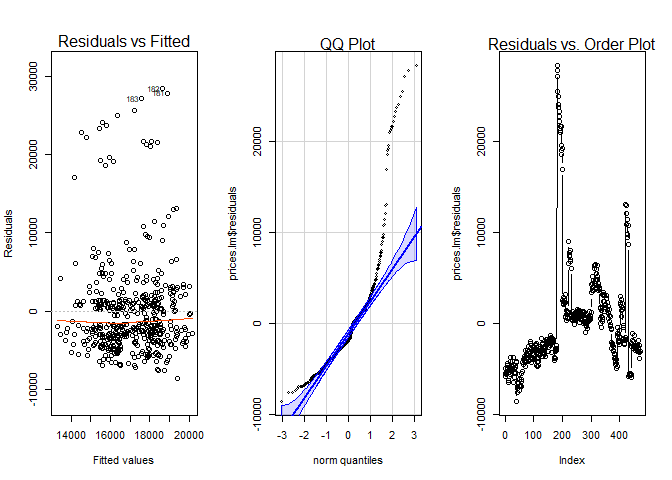

```r
par(mfrow = c(1,3))
plot(prices.lm, which = 1)
qqPlot(prices.lm$residuals, id = FALSE)
mtext(side = 3, text = "QQ Plot")
plot(prices.lm$residuals, type = "b")
mtext(side = 3, text = "Residuals vs. Order Plot")
```

These plots aren’t the prettiest to look at. The Q-Q plot shows a definite curvature and goes way beyond the boundary lines. The Residuals vs. Fitted plot has a slight megaphone shape to it which could be of concern. Nevertheless, I shall continue with this test.

## Test and Trendlines

```r
pander(summary(prices.lm), caption = "Linear Regression Test")
```

|  | Estimate | Std. Error | t value | Pr(>\|t\|) |
| --- | --- | --- | --- | --- |
| **(Intercept)** | 19467 | 879.9 | 22.12 | 1.143e-74 |
| **Mileage** | -0.1547 | 0.04132 | -3.742 | 0.000205 |
| **MakePontiac** | 756.4 | 1554 | 0.4867 | 0.6267 |
| **Mileage:MakePontiac** | 0.06088 | 0.07381 | 0.8249 | 0.4099 |

Linear Regression Test

| Observations | Residual Std. Error | $R^2$ | Adjusted $R^2$ |
| --- | --- | --- | --- |
| 470 | 6055 | 0.05539 | 0.04931 |

As it can be seen, there is sufficient evidence to reject one of the null hypotheses made earlier. With a $p$-value of **0.000205**, there is sufficient evidence to say that the slope of the Chevrolet line is not equal to zero. On the other hand, there is insufficient evidence to say that the difference in the two slopes, $\beta_3$, is not equal to zero. If you look at the **Mileage:MakePontiac** Estimate (which is $\beta_3$), you can clearly see that it is a small number relatively speaking. So, this conclusion is a logical one.

Using this information, I can make trendlines that fit this data.

Here we can see that same scatterplot of the data with the trendlines on it.

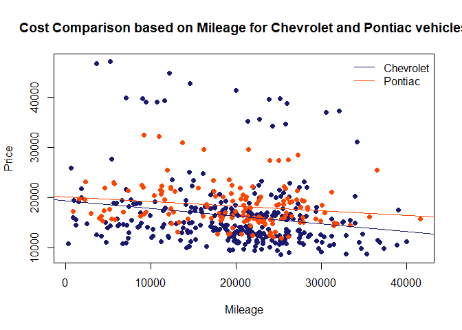

```r
B <- prices.lm$coefficients
plot(Price ~ Mileage, data = CarPrices1, col = as.factor(Make), pch = 16, main = "Cost Comparison based on Mileage for Chevrolet and Pontiac vehicles")
legend("topright", legend = c("Chevrolet", "Pontiac"), bty = "n", lty = 1, col = palette())
abline(B[1], B[2], col = palette()[1], lty = 1, lwd = 1)
abline((B[1] + B[3]), (B[2] + B[4]), col = palette()[2], lty = 1, lwd =1)
```